# Analytics Edge: Unit 3 - Predicting the Winner Before any Votes are Cast

Sulman Khan

October 26, 2018

## Election Forecasting

### United States Presidential Elections

- A president is elected every four years
- Generally, only two competitive candidates
  - Republican
  - Democratic

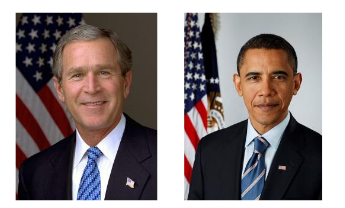

### The Electoral College

- The United States have 50 states
- Each assigned a number of *electoral votes* based on population
  - Most votes: 55 (California)
  - Least votes: 3 (multiple states)
  - Reassigned periodically based on population changes
- Winner takes all: candidate with the most votes in a state gets all its electoral votes
- Candidate with most electoral votes win election

### 2000 Election: Bush vs Gore

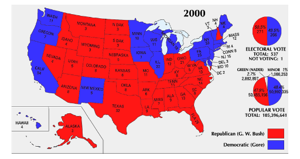

### Election Prediction

- Goal: Use polling data to predict state winners
- Then - *New York Times* columnist Nate Silver famously took on this task for the 2012 election

### The Dataset

- Data from RealClearPolitics.com
- Instances represent a state in a given election
  - *State*: Name of state
  - *Year*: Election year (2004, 2008, 20012)
- Dependent variable
  - *Republican*: 1 if Republican won state, 0 if Democrat won
- Independent variables
  - *Rasmussen, SurveyUSA*: Polled R% - Polled D%
  - *DiffCount*: Polls with R winner - Polls with D winner
  - *PrepR*: Polls with R winner / # polls

### Simple Approaches to Missing Data

- Delete the missing observations
  - We would be throwing away more than 50% of the data
  - We want to predict for all states
- Delete variables with missing values
  - We want to retain data from Rasmussen/SurveyUSA
- Fill missing data points with average values
  - The average value for a poll will be close to 0 (tie between Democrat and Republican)
  - If other polls in a state favor one candidate, the missing one probably would have, too

### Multiple Imputation

- Fill in missing values based on non-missing values
  - If Rasmussen is very negative, then a missing SurveyUSA value will likely be negative
  - Just like *sample.split* results will differ between runs unless you fix the random seed
- Although the method is complicated, we can use it easily through R’s libraries
- We will use Multiple Imputation by Chained Equations (mice) package

### Election Forecasting in R

### Load in the data

```r
# Read in data
polling = read.csv("PollingData.csv")
str(polling)
```

```
## 'data.frame':    145 obs. of  7 variables:
##  $ State     : Factor w/ 50 levels "Alabama","Alaska",..: 1 1 2 2 3 3 3 4 4 4 ...
##  $ Year      : int  2004 2008 2004 2008 2004 2008 2012 2004 2008 2012 ...
##  $ Rasmussen : int  11 21 NA 16 5 5 8 7 10 NA ...
##  $ SurveyUSA : int  18 25 NA NA 15 NA NA 5 NA NA ...
##  $ DiffCount : int  5 5 1 6 8 9 4 8 5 2 ...
##  $ PropR     : num  1 1 1 1 1 ...
##  $ Republican: int  1 1 1 1 1 1 1 1 1 1 ...
```

```r
z = table(polling$Year)
kable(z)
```

| Var1 | Freq |
| --- | --- |
| 2004 | 50 |
| 2008 | 50 |
| 2012 | 45 |

```r
z = summary(polling)
kable(z)
```

|  | State | Year | Rasmussen | SurveyUSA | DiffCount | PropR | Republican |
| --- | --- | --- | --- | --- | --- | --- | --- |
|  | Arizona : 3 | Min. :2004 | Min. :-41.0000 | Min. :-33.0000 | Min. :-19.000 | Min. :0.0000 | Min. :0.0000 |
|  | Arkansas : 3 | 1st Qu.:2004 | 1st Qu.: -8.0000 | 1st Qu.:-11.7500 | 1st Qu.: -6.000 | 1st Qu.:0.0000 | 1st Qu.:0.0000 |
|  | California : 3 | Median :2008 | Median : 1.0000 | Median : -2.0000 | Median : 1.000 | Median :0.6250 | Median :1.0000 |
|  | Colorado : 3 | Mean :2008 | Mean : 0.0404 | Mean : -0.8243 | Mean : -1.269 | Mean :0.5259 | Mean :0.5103 |
|  | Connecticut: 3 | 3rd Qu.:2012 | 3rd Qu.: 8.5000 | 3rd Qu.: 8.0000 | 3rd Qu.: 4.000 | 3rd Qu.:1.0000 | 3rd Qu.:1.0000 |
|  | Florida : 3 | Max. :2012 | Max. : 39.0000 | Max. : 30.0000 | Max. : 11.000 | Max. :1.0000 | Max. :1.0000 |
|  | (Other) :127 | NA | NA’s :46 | NA’s :71 | NA | NA | NA |

### Load mice package

```r
# Load mice package
library(mice)
```

### Multiple imputations

```r
# Multiple imputation
simple = polling[c("Rasmussen", "SurveyUSA", "PropR", "DiffCount")]
z = summary(simple)
kable(z)
```

|  | Rasmussen | SurveyUSA | PropR | DiffCount |
| --- | --- | --- | --- | --- |
|  | Min. :-41.0000 | Min. :-33.0000 | Min. :0.0000 | Min. :-19.000 |
|  | 1st Qu.: -8.0000 | 1st Qu.:-11.7500 | 1st Qu.:0.0000 | 1st Qu.: -6.000 |
|  | Median : 1.0000 | Median : -2.0000 | Median :0.6250 | Median : 1.000 |
|  | Mean : 0.0404 | Mean : -0.8243 | Mean :0.5259 | Mean : -1.269 |
|  | 3rd Qu.: 8.5000 | 3rd Qu.: 8.0000 | 3rd Qu.:1.0000 | 3rd Qu.: 4.000 |
|  | Max. : 39.0000 | Max. : 30.0000 | Max. :1.0000 | Max. : 11.000 |
|  | NA’s :46 | NA’s :71 | NA | NA |

### Split the data

```r
# Split the data
set.seed(144)
imputed = complete(mice(simple))
z = summary(imputed)
kable(z)
```

|  | Rasmussen | SurveyUSA | PropR | DiffCount |
| --- | --- | --- | --- | --- |
|  | Min. :-41.000 | Min. :-33.000 | Min. :0.0000 | Min. :-19.000 |
|  | 1st Qu.: -8.000 | 1st Qu.:-11.000 | 1st Qu.:0.0000 | 1st Qu.: -6.000 |
|  | Median : 3.000 | Median : 1.000 | Median :0.6250 | Median : 1.000 |
|  | Mean : 1.731 | Mean : 1.517 | Mean :0.5259 | Mean : -1.269 |
|  | 3rd Qu.: 11.000 | 3rd Qu.: 18.000 | 3rd Qu.:1.0000 | 3rd Qu.: 4.000 |
|  | Max. : 39.000 | Max. : 30.000 | Max. :1.0000 | Max. : 11.000 |

```r
polling$Rasmussen = imputed$Rasmussen
polling$SurveyUSA = imputed$SurveyUSA
z = summary(polling)
kable(z)
```

|  | State | Year | Rasmussen | SurveyUSA | DiffCount | PropR | Republican |
| --- | --- | --- | --- | --- | --- | --- | --- |
|  | Arizona : 3 | Min. :2004 | Min. :-41.000 | Min. :-33.000 | Min. :-19.000 | Min. :0.0000 | Min. :0.0000 |
|  | Arkansas : 3 | 1st Qu.:2004 | 1st Qu.: -8.000 | 1st Qu.:-11.000 | 1st Qu.: -6.000 | 1st Qu.:0.0000 | 1st Qu.:0.0000 |
|  | California : 3 | Median :2008 | Median : 3.000 | Median : 1.000 | Median : 1.000 | Median :0.6250 | Median :1.0000 |
|  | Colorado : 3 | Mean :2008 | Mean : 1.731 | Mean : 1.517 | Mean : -1.269 | Mean :0.5259 | Mean :0.5103 |
|  | Connecticut: 3 | 3rd Qu.:2012 | 3rd Qu.: 11.000 | 3rd Qu.: 18.000 | 3rd Qu.: 4.000 | 3rd Qu.:1.0000 | 3rd Qu.:1.0000 |
|  | Florida : 3 | Max. :2012 | Max. : 39.000 | Max. : 30.000 | Max. : 11.000 | Max. :1.0000 | Max. :1.0000 |
|  | (Other) :127 | NA | NA | NA | NA | NA | NA |

```r
Train = subset(polling, Year == 2004 | Year == 2008)
Test = subset(polling, Year == 2012)
```

### Baseline

```r
# Smart Baseline
z = table(Train$Republican)
kable(z)
```

| Var1 | Freq |
| --- | --- |
| 0 | 47 |
| 1 | 53 |

```r
sign(20)
```

```
## [1] 1
```

```r
sign(-10)
```

```
## [1] -1
```

```r
sign(0)
```

```
## [1] 0
```

```r
z = table(sign(Train$Rasmussen))
kable(z)
```

| Var1 | Freq |
| --- | --- |
| -1 | 42 |
| 0 | 3 |
| 1 | 55 |

```r
z = table(Train$Republican, sign(Train$Rasmussen))
kable(z)
```

|  | -1 | 0 | 1 |
| --- | --- | --- | --- |
| 0 | 42 | 2 | 3 |
| 1 | 0 | 1 | 52 |

### Multicollinearity

```r
# Multicollinearity
cor(Train[c("Rasmussen", "SurveyUSA", "PropR", "DiffCount", "Republican")])
```

```
##            Rasmussen SurveyUSA     PropR DiffCount Republican
## Rasmussen  1.0000000 0.9194508 0.8404803 0.5124098  0.8021191
## SurveyUSA  0.9194508 1.0000000 0.8756581 0.5541816  0.8205806
## PropR      0.8404803 0.8756581 1.0000000 0.8273785  0.9484204
## DiffCount  0.5124098 0.5541816 0.8273785 1.0000000  0.8092777
## Republican 0.8021191 0.8205806 0.9484204 0.8092777  1.0000000
```

### Logistic Regression

```r
# Logistic Regression Model
mod1 = glm(Republican~PropR, data=Train, family="binomial")
summary(mod1)
```

```
##
## Call:
## glm(formula = Republican ~ PropR, family = "binomial", data = Train)
##
## Deviance Residuals:
##      Min        1Q    Median        3Q       Max
## -2.22880  -0.06541   0.10260   0.10260   1.37392
##
## Coefficients:
##             Estimate Std. Error z value Pr(>|z|)
## (Intercept)   -6.146      1.977  -3.108 0.001882 **
## PropR         11.390      3.153   3.613 0.000303 ***
## ---
## Signif. codes:  0 '***' 0.001 '**' 0.01 '*' 0.05 '.' 0.1 ' ' 1
##
## (Dispersion parameter for binomial family taken to be 1)
##
##     Null deviance: 138.269  on 99  degrees of freedom
## Residual deviance:  15.772  on 98  degrees of freedom
## AIC: 19.772
##
## Number of Fisher Scoring iterations: 8
```

### Make predictions

```r
# Training set predictions
pred1 = predict(mod1, type="response")
z = table(Train$Republican, pred1 >= 0.5)
kable(z)
```

[output not shown]

```r
# Two-variable model
mod2 = glm(Republican~SurveyUSA+DiffCount, data=Train, family="binomial")
# Make predictions
pred2 = predict(mod2, type="response")
z = table(Train$Republican, pred2 >= 0.5)
kable(z)
```

|  | FALSE | TRUE |
| --- | --- | --- |
| 0 | 45 | 2 |
| 1 | 1 | 52 |

```r
summary(mod2)
```

```
##
## Call:
## glm(formula = Republican ~ SurveyUSA + DiffCount, family = "binomial",
##     data = Train)
##
## Deviance Residuals:
##      Min        1Q    Median        3Q       Max
## -2.01196  -0.00698   0.01005   0.05074   1.54975
##
## Coefficients:
##             Estimate Std. Error z value Pr(>|z|)
## (Intercept)  -1.1405     1.2456  -0.916   0.3599
## SurveyUSA     0.2976     0.1949   1.527   0.1267
## DiffCount     0.7673     0.4188   1.832   0.0669 .
## ---
## Signif. codes:  0 '***' 0.001 '**' 0.01 '*' 0.05 '.' 0.1 ' ' 1
##
## (Dispersion parameter for binomial family taken to be 1)
##
##     Null deviance: 138.269  on 99  degrees of freedom
## Residual deviance:  12.439  on 97  degrees of freedom
## AIC: 18.439
##
## Number of Fisher Scoring iterations: 10
```

### Analysis

```r
# Smart baseline accuracy
z = table(Test$Republican, sign(Test$Rasmussen))
kable(z)
```

|  | -1 | 0 | 1 |
| --- | --- | --- | --- |
| 0 | 18 | 2 | 4 |
| 1 | 0 | 0 | 21 |

```r
# Test set predictions
TestPrediction = predict(mod2, newdata=Test, type="response")
z = table(Test$Republican, TestPrediction >= 0.5)
kable(z)
```

|  | FALSE | TRUE |
| --- | --- | --- |
| 0 | 23 | 1 |
| 1 | 0 | 21 |

```r
# Analyze mistake
subset(Test, TestPrediction >= 0.5 & Republican == 0)
```

```
##      State Year Rasmussen SurveyUSA DiffCount     PropR Republican
## 24 Florida 2012         2         0         6 0.6666667          0
```